# Legionellen 2025 – Datenaufbereitung, Adressstandardisierung und Aggregation

03.02.2026

## 1 Ziel und Kontext

Nach § 53 Abs. 4 Trinkwasserverordnung (TrinkwV) sind zugelassene Trinkwasseruntersuchungsstellen verpflichtet, Daten zu den im vorangegangenen Kalenderjahr durchgeführten Legionellenuntersuchungen zusammenfassend zu melden.  
In diesem Dokument wird nachvollziehbar beschrieben, wie aus LIMS-Exportdaten (`LDM_Abfragesicht_9`):

- einheitlich interpretierbare Messwerte (inkl. `>…` / `<…`-Eingaben),
- bereinigte und konsolidierte Adressen,
- sowie die geforderten Zählkennzahlen

abgeleitet werden.

## 2 Überblick über den Workflow

Der technische Ablauf besteht aus fünf Bausteinen:

1. **Einlesen und Zusammenführen** der Excel-Exports aus mehreren Referaten
2. **Identifikation der relevanten Proben**, d.h. Berücksichtigung ausschlißlich von Untersuchungen nach §31
3. **Interpretation der Ergebnisfelder** (Strings wie `>2` als numerisch interpretierbar machen)
4. **Adressbereinigung und Deduplikation** (deterministisch + fehlertolerant)
5. **Aggregation** der Ergebnisse pro Referat und als Gesamtsumme

Die folgenden Abschnitte dokumentieren die Schritte und Annahmen.

## 3 Annahme: Adresse als Surrogat für Trinkwasserinstallation

Die UBA-Meldung fragt u.a. nach der *Anzahl der untersuchten Trinkwasserinstallationen* sowie nach Installationen/Proben, bei denen der technische Maßnahmenwert erreicht wurde.

Da in den LIMS-Exportdaten in der vorliegenden Struktur keine eindeutige, systemweit stabile Installations-ID vorhanden ist, wird **die bereinigte Adresse (`addr_final`) als Surrogat für eine Installation** verwendet.

**Praktische Bedeutung dieser Annahme:**

- Mehrere Proben derselben Adresse werden derselben Installation zugeordnet.
- Adressvarianten (Tippfehler, Abkürzungen, Zusatztexte) werden soweit möglich vereinheitlicht.
- Diese Annäherung ersetzt aber keine echte, eindeutige Installations-Referenz im System.
- Bei Großeinrichtungen mit mehreren Installationen an einer Adresse wird die Zahl der Installationen unterschätzt.
- Bei unkorrigierten Adressvarianten wird die Anzahl der Installationen überschätzt.

## 4 Adressbereinigung und Wiederverwendbarkeit

### 4.1 Motivation

Mitarbeiterinnen in der Datenerfassung nutzen bisweilen keine im System Hinterlegten Adressen, sondern erstellen Neueingaben. IM den LIMS liegen Adressen als Kombination mehrerer Felder vor (Straße, Ort, Gemeinde, Einrichtungenamen etc.), dadurch entstehen Varianten derselben Adresse, z.B.:

- unterschiedliche Schreibweisen (`Str.` / `Straße` / `strasse`)
- Tippfehler (`waisenhausstrr`)
- zusammengezogene Tokens (`nordallee1`)
- Zusatzinformationen (Einrichtungsname hinter der Hausnummer)

### 4.2 Vorgehen

Die Adressaufbereitung ist modular aufgebaut und gliedert sich in:

- **Schritt 1 (deterministisch):** Regelbasierte Normalisierung (z.B. `Str.` → `strasse`, Vereinheitlichung von Leerzeichen, Trennung zusammengezogener Tokens)
- **Schritt 2a (key-basiert):** Zusammenführen innerhalb gleicher PLZ+Ort, Entfernen von Zusatztext hinter der Hausnummer
- **Schritt 2b (fuzzy):** Fehlertoleranter Abgleich **nur des Straßennamens**, bei **exakter Hausnummer**, innerhalb PLZ+Ort

Der Vorteil dieser Struktur ist, dass der gesamte Adress-Block **als wiederverwendbares Modul** für weitere Projekte eingesetzt werden kann (z.B. andere Parameter, andere Berichtsjahre, andere Auswertungen), ohne den restlichen Analysecode ändern zu müssen.

## 5 Technischer Teil: Code

### 5.1 Pakete

```r
library(readxl)
library(dplyr)
library(stringr)
library(stringi)
library(stringdist)
library(igraph)
library(knitr)
library(magrittr)
library(lubridate)
library(ggplot2)
library(scales)
library(tidyr)
```

### 5.2 Einlesen und Zusammenführen der Exporte

```r
files <- sapply(c(
  "O:/Abteilung Humanmedizin (AHM)/Referat 32/32_6/Legionella Project/LIMS_2_RIDOM/Referat_31/",
  "O:/Abteilung Humanmedizin (AHM)/Referat 32/32_6/Legionella Project/LIMS_2_RIDOM/Referat_32/",
  "O:/Abteilung Humanmedizin (AHM)/Referat 32/32_6/Legionella Project/LIMS_2_RIDOM/Referat_33/"
), list.files, pattern = ".*2025*.xls", full.names = TRUE) |>
  unlist(use.names = FALSE)

xl_list <- lapply(files, read_excel)
common_colnames <- Reduce(intersect, lapply(xl_list, colnames))
LIMS <- do.call(rbind, lapply(xl_list, function (x) x[, common_colnames]))

LIMS$Ref <- substr(LIMS$Labornummer, 1, 2)
```

### 5.3 Identifizieren und Auswahl der Utersuchungen nach §31

```r
# Übersicht: Material-Ausprägungen
table(LIMS$Material, useNA = "ifany")
```

```
##
##                   Trinkwasser nur Legionellen
##                                           843
##     Trinkwasser nur Legionellen + Typisierung
##                                           677
##               Trinkwasser nur Legionellen §31
##                                           665
## Trinkwasser nur Legionellen §31 + Typisierung
##                                           438
```

```r
# Übersicht: §31-Flag (korrekt: pattern ist "§31")
table(grepl("§31", LIMS$Material), useNA = "ifany")
```

```
##
## FALSE  TRUE
##  1520  1103
```

```r
# Subset: nur §31
LIMS <- LIMS %>%
  filter(grepl("§31", Material))

# Kontrolle nach Subset
table(LIMS$Material, useNA = "ifany")
```

```
##
##               Trinkwasser nur Legionellen §31
##                                           665
## Trinkwasser nur Legionellen §31 + Typisierung
##                                           438
```

### 5.4 Ergebnisfelder interpretieren (`>…`, `<…`, exakt)

```r
LIMS <- LIMS %>%
  mutate(
    Accuracy = case_when(
      str_detect(Ergebnis...19, ">") ~ "gr",
      str_detect(Ergebnis...19, "<") ~ "kl",
      !is.na(suppressWarnings(as.numeric(Ergebnis...19))) ~ "exa",
      TRUE ~ NA_character_
    ),
    KolNum = suppressWarnings(as.numeric(gsub(">|<|\\s+", "", Ergebnis...19)))
  )
```

### 5.5 Adresse zusammensetzen (Rohform)

```r
LIMS <- LIMS %>%
  mutate(
    adresse = paste(
      Straße...9,
      Gemeinde, Ort,
      Einrichtung, `Name des Bades`,
      PLZ
    )
  )
```

### 5.6 Adressbereinigung und Deduplikation (Modul)

```r
norm_txt <- function(x) {
  x <- ifelse(is.na(x), "", x)
  x <- str_squish(x)
  x <- str_to_lower(x)

  x <- str_replace_all(x, "\\bna\\b", "")
  x <- stringi::stri_trans_general(x, "de-ASCII")
  x <- str_replace_all(x, "ß", "ss")

  x <- str_replace_all(x, "[,;]", " ")
  x <- str_replace_all(x, "\\s+", " ")
  x <- str_trim(x)

  x <- str_replace_all(x, "\\bstraße\\b", "strasse")
  x <- str_replace_all(x, "\\bstr\\.?\\b", "strasse")

  x <- str_replace_all(x, "([[:alpha:]])strasse\\b", "\\1 strasse")
  x <- str_replace_all(x, "([[:alpha:]])str\\.?\\b", "\\1 strasse")

  x <- str_replace_all(x, "strr\\b", "strasse")

  x <- str_replace_all(x, "-", " ")
  x <- str_replace_all(x, "([[:alpha:]])platz\\b", "\\1 platz")

  x <- str_replace_all(x, "([[:alpha:]])allee\\b", "\\1 allee")
  x <- str_replace_all(x, "\\ballee(?=\\d)", "allee ")

  x <- str_replace_all(x, "\\.(?=\\s|$)", "")

  x <- str_replace_all(x, "(\\d)\\s*\\+\\s*(\\d)", "\\1-\\2")
  x <- str_replace_all(x, "(\\d)\\s*-\\s*(\\d)", "\\1-\\2")

  x <- str_replace_all(x, "\\bstrasse(?=\\d)", "strasse ")

  str_squish(x)
}

pick_city <- function(gemeinde, ort) {
  g <- norm_txt(gemeinde)
  o <- norm_txt(ort)
  ifelse(o == "" | o == g, g, o)
}

make_short_address <- function(street, plz, city) {
  s <- norm_txt(street)
  p <- str_extract(norm_txt(plz), "\\b\\d{5}\\b")
  p <- ifelse(is.na(p), "", p)
  c <- norm_txt(city)

  out <- str_squish(paste0(s, ", ", p, " ", c))
  out <- str_replace_all(out, "^,\\s*", "")
  out <- str_replace_all(out, ",\\s*$", "")
  out
}

extract_street_hnr <- function(short_addr_norm) {
  pre <- str_trim(str_extract(short_addr_norm, "^[^,]+"))
  street_hnr <- str_trim(str_extract(
    pre,
    "^[[:alpha:] .]+\\s*\\d+[[:alpha:]]?(?:\\s*-\\s*\\d+[[:alpha:]]?)?"
  ))
  ifelse(is.na(street_hnr) | street_hnr == "", pre, street_hnr)
}

split_street_hnr <- function(street_hnr) {
  x <- norm_txt(street_hnr)
  hnr <- str_extract(x, "\\b\\d+[[:alpha:]]?(?:-\\d+[[:alpha:]]?)?\\b\\s*$")
  hnr <- str_trim(ifelse(is.na(hnr), "", hnr))
  street <- str_trim(str_replace(x, "\\b\\d+[[:alpha:]]?(?:-\\d+[[:alpha:]]?)?\\b\\s*$", ""))
  street <- str_squish(street)
  tibble(street_name = street, hnr_exact = hnr)
}

cluster_streetnames <- function(street_names, method = "jw", max_dist = 0.10) {
  u <- unique(street_names)
  u <- u[!is.na(u) & u != ""]
  if (length(u) <= 1) return(rep(1L, length(street_names)))

  D <- stringdist::stringdistmatrix(u, u, method = method)
  adj <- (D <= max_dist) & (row(D) != col(D))
  g <- igraph::graph_from_adjacency_matrix(adj, mode = "undirected", diag = FALSE)

  memb <- igraph::components(g)$membership
  names(memb) <- u
  as.integer(memb[street_names])
}

LIMS2 <- LIMS %>%
  mutate(
    city = pick_city(Gemeinde, Ort),
    short_addr = make_short_address(`Straße...9`, PLZ, city)
  ) %>%
  mutate(
    short_addr_norm = norm_txt(short_addr),
    plz_norm  = str_extract(short_addr_norm, "\\b\\d{5}\\b"),
    plz_norm  = ifelse(is.na(plz_norm), "", plz_norm),
    city_norm = norm_txt(city),
    street_hnr = extract_street_hnr(short_addr_norm),
    addr_key = str_squish(paste(plz_norm, city_norm, street_hnr))
  ) %>%
  group_by(plz_norm, city_norm, addr_key) %>%
  mutate(
    short_addr_keymerge = short_addr[which.min(nchar(short_addr))]
  ) %>%
  ungroup()

tmp <- split_street_hnr(LIMS2$street_hnr)

LIMS2 <- LIMS2 %>%
  bind_cols(tmp) %>%
  group_by(plz_norm, city_norm, hnr_exact) %>%
  mutate(
    street_cluster = cluster_streetnames(street_name, method = "jw", max_dist = 0.10)
  ) %>%
  group_by(plz_norm, city_norm, hnr_exact, street_cluster) %>%
  mutate(
    street_name_canon = names(which.max(table(street_name))),
    addr_final = str_squish(paste0(street_name_canon, " ", hnr_exact, ", ", plz_norm, " ", city_norm))
  ) %>%
  ungroup()

options(tibble.width = Inf)

LIMS2 %>%
  group_by(addr_final) %>%
  summarise(
    n_street_variants = n_distinct(Straße...9),
    p_street_v = paste(unique(Straße...9), collapse = " / "),
    .groups = "drop"
  )  %>%
  arrange(desc(n_street_variants))
```

```
## # A tibble: 115 × 3
##    addr_final                                     n_street_variants
##    <chr>                                                      <int>
##  1 ernestus platz 1, 56626 andernach                              3
##  2 avallon strasse 1, 56812 cochem                                2
##  3 avallon strasse 32, 56812 cochem                               2
##  4 bodelschwingh strasse 27, 76829 landau                         2
##  5 buchen strasse 6, 56588 waldbreitbach                          2
##  6 hanns martin schleyer strasse 30, 76744 woerth                 2
##  7 himmeroder strasse 88, 54516 wittlich                          2
##  8 koblenzer strasse 115, 56073 koblenz                           2
##  9 luitpold strasse 14, 76870 kandel                              2
## 10 paul egell strasse 33, 67346 speyer                            2
##    p_street_v
##    <chr>
##  1 Ernestus-Platz 1 / Ernestusplatz 1 / Ernestus Platz 1
##  2 Avallonstraße 1 / Avallonstr. 1
##  3 Avallonstr. 32 / Avallonstraße 32
##  4 Bodelschwinghstraße 27 / Bodelschwinghstr. 27
##  5 Buchenstraße 6 / Buchenstr. 6
##  6 Hanns-Martin-Schleyer-Str.30 / Hanns-Martin-Schleyer-Str. 30
##  7 Himmeroder Straße 88 / Himmeroderstr. 88
##  8 Koblenzer Str. 115 - 155 / Koblenzer Straße 115-155
##  9 Luitpoldstraße 14 / Luitpoldstr. 14
## 10 Paul-Egell-Str. 33 / Paul-Egell-Straße 33
## # ℹ 105 more rows
```

## 6 Aggregation für die UBA-Tabelle

Für die Meldung werden die folgenden Kennzahlen benötigt:

- Anzahl untersuchter Installationen (hier: `addr_final`)
- Anzahl Installationen, bei denen der technische Maßnahmenwert erreicht wurde
- Anzahl untersuchter Proben (Zeilen)
- Anzahl Proben, bei denen der technische Maßnahmenwert erreicht wurde

```r
TMW_LEG <- 100  # technischer Maßnahmenwert Legionellen (KBE/100 ml)

df_leg <- LIMS2 %>%
  mutate(
    installation = addr_final,
    tmw_reached = case_when(
      !is.na(KolNum) & Accuracy %in% c("exa", "gr") & KolNum >= TMW_LEG ~ TRUE,
      TRUE ~ FALSE
    )
  ) %>%
  filter(!is.na(installation), installation != "") %>%
  filter(!is.na(Ref), Ref != "") %>%
  filter(!is.na(KolNum))

uba_by_ref <- df_leg %>%
  group_by(Ref) %>%
  summarise(
    anzahl_installationen_untersucht = n_distinct(installation),
    anzahl_installationen_mit_tmw = n_distinct(installation[tmw_reached]),
    anzahl_proben_untersucht = n(),
    anzahl_proben_mit_tmw = sum(tmw_reached, na.rm = TRUE),
    .groups = "drop"
  ) %>%
  arrange(Ref)

uba_gesamt <- df_leg %>%
  summarise(
    anzahl_installationen_untersucht = n_distinct(installation),
    anzahl_installationen_mit_tmw = n_distinct(installation[tmw_reached]),
    anzahl_proben_untersucht = n(),
    anzahl_proben_mit_tmw = sum(tmw_reached, na.rm = TRUE)
  )
```

```r
kable(
  uba_by_ref,
  col.names = c(
    "Referat",
    "Untersuchte Installationen",
    "Installationen ≥ TMW",
    "Untersuchte Proben",
    "Proben ≥ TMW"
  ),
  align = "lrrrr",
  caption = "Übersicht der Meldedaten nach Referat"
)
```

Übersicht der Meldedaten nach Referat

| Referat | Untersuchte Installationen | Installationen ≥ TMW | Untersuchte Proben | Proben ≥ TMW |
| --- | --- | --- | --- | --- |
| 31 | 19 | 3 | 198 | 12 |
| 32 | 76 | 23 | 637 | 56 |
| 33 | 19 | 5 | 231 | 18 |

```r
kable(
  uba_gesamt,
  col.names = c(
    "Untersuchte Installationen",
    "Installationen ≥ TMW",
    "Untersuchte Proben",
    "Proben ≥ TMW"
  ),
  align = "rrrr",
  caption = "Gesamtsumme (alle Referate zusammen)"
)
```

Gesamtsumme (alle Referate zusammen)

| Untersuchte Installationen | Installationen ≥ TMW | Untersuchte Proben | Proben ≥ TMW |
| --- | --- | --- | --- |
| 114 | 31 | 1066 | 86 |

## 8 Ergebnisübersicht (Details zur Plausibilitätsprüfung)

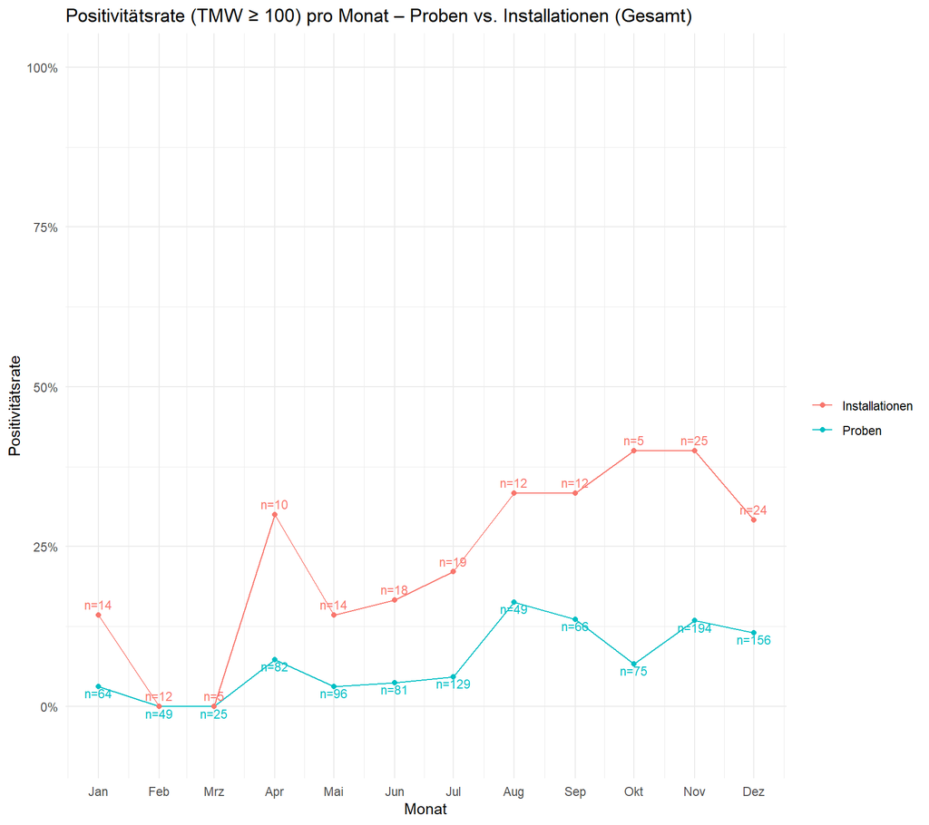

```r
library(dplyr)
library(lubridate)
library(ggplot2)
library(scales)
library(tidyr)

TMW_LEG <- 100  # Maßnahmenwert

# Datumsspalte (bereits vorhanden)
LIMS2$datum <- as.Date(LIMS2$`Probenahme  (Datum)`)

# Basisdaten für Zeitreihen
df_time <- LIMS2 %>%
  mutate(
    tmw_reached = case_when(
      !is.na(KolNum) & Accuracy %in% c("exa", "gr") & KolNum >= TMW_LEG ~ TRUE,
      TRUE ~ FALSE
    ),
    month = floor_date(datum, "month")
  ) %>%
  filter(!is.na(month)) %>%
  filter(!is.na(Ref), Ref != "") %>%
  filter(!is.na(addr_final), addr_final != "") %>%
  filter(!is.na(KolNum))

# --- Installation positiv, wenn im Monat irgendeine Probe positiv ist
inst_month <- df_time %>%
  group_by(month, addr_final) %>%
  summarise(inst_pos = any(tmw_reached, na.rm = TRUE), .groups = "drop")

inst_month_ref <- df_time %>%
  group_by(Ref, month, addr_final) %>%
  summarise(inst_pos = any(tmw_reached, na.rm = TRUE), .groups = "drop")

# --- Monatsaggregation gesamt: Proben- und Installationsrate
mon_all <- df_time %>%
  group_by(month) %>%
  summarise(
    n_proben = n(),
    pos_proben = sum(tmw_reached, na.rm = TRUE),
    rate_proben = pos_proben / n_proben,
    .groups = "drop"
  ) %>%
  left_join(
    inst_month %>%
      group_by(month) %>%
      summarise(
        n_inst = n(),
        pos_inst = sum(inst_pos, na.rm = TRUE),
        rate_inst = pos_inst / n_inst,
        .groups = "drop"
      ),
    by = "month"
  )

plot_all <- mon_all %>%
  transmute(
    month,
    `Proben` = rate_proben,
    `Installationen` = rate_inst,
    n_proben, n_inst
  ) %>%
  pivot_longer(cols = c("Proben", "Installationen"),
               names_to = "Einheit", values_to = "rate") %>%
  mutate(
    n_label = ifelse(Einheit == "Proben",
                     paste0("n=", n_proben),
                     paste0("n=", n_inst))
  )

# --- Monatsaggregation pro Referat: Proben- und Installationsrate
mon_ref <- df_time %>%
  group_by(Ref, month) %>%
  summarise(
    n_proben = n(),
    pos_proben = sum(tmw_reached, na.rm = TRUE),
    rate_proben = pos_proben / n_proben,
    .groups = "drop"
  ) %>%
  left_join(
    inst_month_ref %>%
      group_by(Ref, month) %>%
      summarise(
        n_inst = n(),
        pos_inst = sum(inst_pos, na.rm = TRUE),
        rate_inst = pos_inst / n_inst,
        .groups = "drop"
      ),
    by = c("Ref", "month")
  ) %>%
  mutate(
    Ref = paste("Referat", Ref)  # Facet-Label erweitern
  )

plot_ref <- mon_ref %>%
  transmute(
    Ref, month,
    `Proben` = rate_proben,
    `Installationen` = rate_inst,
    n_proben, n_inst
  ) %>%
  pivot_longer(cols = c("Proben", "Installationen"),
               names_to = "Einheit", values_to = "rate") %>%
  mutate(
    n_label = ifelse(Einheit == "Proben",
                     paste0("n=", n_proben),
                     paste0("n=", n_inst))
  )

# --- Gemeinsame y-Limits mit "Luft" nach unten & oben (damit Labels nicht abgeschnitten werden)
y_max <- max(c(plot_all$rate, plot_ref$rate), na.rm = TRUE)
y_pad_up <- 0.05
y_pad_down <- 0.06
y_lim <- c(0 - y_pad_down, min(1, y_max + y_pad_up))

# =========================
# Plot 1: Gesamt
# =========================
ggplot(plot_all, aes(x = month, y = rate, color = Einheit)) +
  geom_line() +
  geom_point() +
  # Installationen: Label über dem Punkt
  geom_text(
    data = subset(plot_all, Einheit == "Installationen"),
    aes(label = n_label),
    vjust = -0.6, size = 3, show.legend = FALSE
  ) +
  # Proben: Label unter dem Punkt
  geom_text(
    data = subset(plot_all, Einheit == "Proben"),
    aes(label = n_label),
    vjust = 1.2, size = 3, show.legend = FALSE
  ) +
  scale_y_continuous(labels = percent_format(accuracy = 1), limits = y_lim) +
  scale_x_date(date_breaks = "1 month", date_labels = "%b") +
  labs(
    title = "Positivitätsrate (TMW ≥ 100) pro Monat – Proben vs. Installationen (Gesamt)",
    x = "Monat",
    y = "Positivitätsrate",
    color = ""
  ) +
  theme_minimal()
```

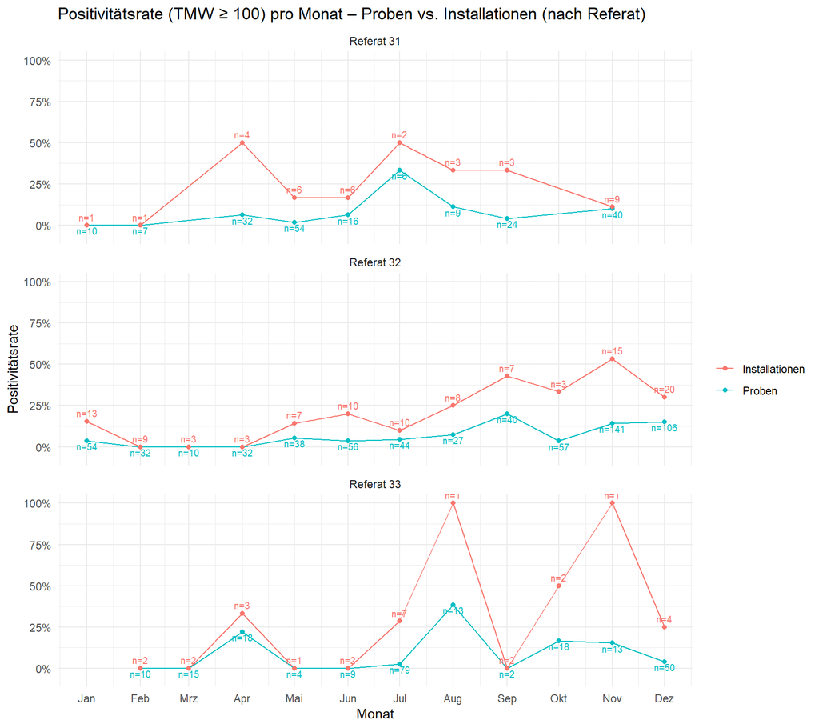

```r
# =========================
# Plot 2: Nach Referat (Facets)
# =========================
ggplot(plot_ref, aes(x = month, y = rate, color = Einheit)) +
  geom_line() +
  geom_point() +
  # Installationen: Label über dem Punkt
  geom_text(
    data = subset(plot_ref, Einheit == "Installationen"),
    aes(label = n_label),
    vjust = -0.6, size = 2.6, show.legend = FALSE
  ) +
  # Proben: Label unter dem Punkt
  geom_text(
    data = subset(plot_ref, Einheit == "Proben"),
    aes(label = n_label),
    vjust = 1.2, size = 2.6, show.legend = FALSE
  ) +
  facet_wrap(~ Ref, ncol = 1) +
  scale_y_continuous(labels = percent_format(accuracy = 1), limits = y_lim) +
  scale_x_date(date_breaks = "1 month", date_labels = "%b") +
  labs(
    title = "Positivitätsrate (TMW ≥ 100) pro Monat – Proben vs. Installationen (nach Referat)",
    x = "Monat",
    y = "Positivitätsrate",
    color = ""
  ) +
  theme_minimal()
```

## 9 Hinweise zur Weiterentwicklung und zu Datenstrukturen im gesamten Amt

Für die vorliegende Auswertung wird die bereinigte Adresse (addr_final) als Surrogat für eine Trinkwasserinstallation verwendet. Dieser Ansatz ist pragmatisch und erhöht die Konsistenz der Aggregation deutlich gegenüber der Nutzung von Rohadressen. Er ermöglicht belastbare Auswertungen auch ohne eine im LIMS verfügbare, eindeutige Installationskennung.

Die Datenqualität ließe sich weiter verbessern, wenn Adressen gegen eine externe Referenzdatenbank abgeglichen würden (z.B. Geocoding, amtliche Adressregister). Dadurch könnten kanonische Schreibweisen sichergestellt, Deduplikation robuster umgesetzt (z.B. über Koordinaten) und Sonderfälle wie Umbenennungen oder Ortsteile besser behandelt werden. Der hier gewählte Ansatz ist bewusst offline und heuristisch gehalten, um ohne externe Abhängigkeiten auskommende, reproduzierbare Auswertungen zu ermöglichen.

Langfristig wäre die höchste Qualität erreichbar, wenn eine solche Referenzierung bereits bei der Dateneingabe im LIMS erfolgt. Mechanismen wie Autovervollständigung, Validierung von Straßen-/PLZ-/Ort-Kombinationen oder feste Installationsobjekte mit eindeutiger ID würden die Adressqualität systemisch verbessern. Dadurch ließen sich nachgelagerte Bereinigungsschritte weitgehend vermeiden und Auswertungen – insbesondere für Meldewesen – deutlich stabiler und effizienter gestalten.